# ラパマイシン処理した細胞の細胞内蛍光輝度の解析

MT

2023-05-02

# 1 この事例で扱うデータと統計

**カテゴリ変数**：細胞の処理条件 `condition`（DMSO, Rapamycin）、細胞内顆粒の有無 `withfoci`（granules, no granules）  
**数値変数**： 細胞内総輝度 `cell_intden`  
**グラフ**：棒グラフ（平均） + エラーバー（1SD） + ドットプロット  
**統計**：Shapiro-Wilk検定によるデータの正規性の検証、Mann-Whitney U-test（ノンパラメトリック）

# 2 データの読み込み

ラパマイシン処理によって細胞内Ade4-mNG顆粒を持つ細胞の割合は減少する。この時ラパマイシンによりTORC1活性が阻害され、タンパク質翻訳が低下することで、Ade4-mNGのタンパク質量が減少したため、顆粒が形成されなかった可能性も考えられた。そこで既存のデータから細胞内のAde4-mNGの総蛍光強度`cell_intden`を改めて測定し、ラパマイシン処理によって変化するかどうか検証する。

```r
library(pacman) # パッケージをまとめてロード
p_load(tidyverse, openxlsx, readxl, ggtext, multcomp, ggsignif, knitr, nparcomp)
```

各細胞内の総蛍光輝度を測定できるよう修正した画像処理スクリプトで再解析。一応、顆粒を持つ細胞の割合も再計算したが、値はほとんど変わらなかった。 フォルダ`prom750R`にcsvファイルをまとめた。読み込んで`bind_rows()`でまとめる。

```r
import_file_path_prom750 <- "prom750R"
list_prom750_cell_data <- list.files("prom750R_foci_data", full.names = T, pattern = "*.csv")
cell_dat <- list_prom750_cell_data %>%
  sapply(., read.csv, header =T, sep = ",", stringsAsFactors = F, simplify = F) %>%
  bind_rows()
```

顆粒の有無を表す変数`withfoci`の値はTrue/Falseなので、わかりやすい値に変換。また処理条件を示す変数`condition`と実験日を表す変数`expday`を追加。

```r
# withfoiの表記を変更
cell_dat <- cell_dat %>%
  mutate(withfoci = if_else(withfoci, "granules", "no granules"))

#処理条件を表す列conditionを作成する
cell_dat <-
  cell_dat %>%
  mutate(condition =case_when(
    str_detect(image_file, "dmso") ~ "DMSO",
    str_detect(image_file, "rapa") ~ "Rapamycin"))

# 実験日を表す列expdayを作成
cell_dat <- cell_dat %>%
  mutate(expday = if_else(str_detect(date, "27R"), "exp1", "exp2"))
```

この時点では`condition`が文字列型なのでfactor型に変換しておく、文字列型のママだと多重検定でエラーになる。また`fct_relevel`でレベル順を変更。

```r
cell_dat$condition <- as_factor(cell_dat$condition)
cell_dat$condition <- fct_relevel(cell_dat$condition, c("DMSO", "Rapamycin"))
```

細胞を一意に同定する変数`cellid`を追加。ファイル名とcell numberを組み合わせる。必要な変数だけを抽出。

```r
cell_dat <- cell_dat %>%
  mutate(cellid = str_c(image_file, cell_number, sep = "_")) %>%
  # 必要な変数だけを残す
  dplyr::select(expday, cellid, image_file, condition, withfoci, cell_intden) %>%
  # tibble形式にしておく
  as_tibble()
cell_dat
```

```
## # A tibble: 18,469 × 6
##    expday cellid               image_file        condition withfoci  cell_intden
##    <chr>  <chr>                <chr>             <fct>     <chr>           <dbl>
##  1 exp1   Ade4_mNG_dmso_009_1  Ade4_mNG_dmso_009 DMSO      granules        2469.
##  2 exp1   Ade4_mNG_dmso_009_2  Ade4_mNG_dmso_009 DMSO      granules        2645.
##  3 exp1   Ade4_mNG_dmso_009_3  Ade4_mNG_dmso_009 DMSO      granules        4336.
##  4 exp1   Ade4_mNG_dmso_009_4  Ade4_mNG_dmso_009 DMSO      granules        3075.
##  5 exp1   Ade4_mNG_dmso_009_5  Ade4_mNG_dmso_009 DMSO      granules        2472.
##  6 exp1   Ade4_mNG_dmso_009_6  Ade4_mNG_dmso_009 DMSO      granules        3130.
##  7 exp1   Ade4_mNG_dmso_009_7  Ade4_mNG_dmso_009 DMSO      granules        3782.
##  8 exp1   Ade4_mNG_dmso_009_8  Ade4_mNG_dmso_009 DMSO      granules        3913.
##  9 exp1   Ade4_mNG_dmso_009_9  Ade4_mNG_dmso_009 DMSO      no granu…       2569.
## 10 exp1   Ade4_mNG_dmso_009_10 Ade4_mNG_dmso_009 DMSO      granules        4460.
## # ℹ 18,459 more rows
```

顆粒を持つ細胞のデータは重複しているので、`dinstinct()`で1つにする。

```r
cell_dat_uni <- cell_dat %>%
  distinct(cellid, .keep_all = TRUE)
cell_dat_uni
```

```
## # A tibble: 13,066 × 6
##    expday cellid               image_file        condition withfoci  cell_intden
##    <chr>  <chr>                <chr>             <fct>     <chr>           <dbl>
##  1 exp1   Ade4_mNG_dmso_009_1  Ade4_mNG_dmso_009 DMSO      granules        2469.
##  2 exp1   Ade4_mNG_dmso_009_2  Ade4_mNG_dmso_009 DMSO      granules        2645.
##  3 exp1   Ade4_mNG_dmso_009_3  Ade4_mNG_dmso_009 DMSO      granules        4336.
##  4 exp1   Ade4_mNG_dmso_009_4  Ade4_mNG_dmso_009 DMSO      granules        3075.
##  5 exp1   Ade4_mNG_dmso_009_5  Ade4_mNG_dmso_009 DMSO      granules        2472.
##  6 exp1   Ade4_mNG_dmso_009_6  Ade4_mNG_dmso_009 DMSO      granules        3130.
##  7 exp1   Ade4_mNG_dmso_009_7  Ade4_mNG_dmso_009 DMSO      granules        3782.
##  8 exp1   Ade4_mNG_dmso_009_8  Ade4_mNG_dmso_009 DMSO      granules        3913.
##  9 exp1   Ade4_mNG_dmso_009_9  Ade4_mNG_dmso_009 DMSO      no granu…       2569.
## 10 exp1   Ade4_mNG_dmso_009_10 Ade4_mNG_dmso_009 DMSO      granules        4460.
## # ℹ 13,056 more rows
```

# 3 データの解析

## 3.1 視野毎に平均化しない場合

`group_nest()`を使用して各条件でグループ分けして、データを畳み込む。各条件における平均とSD、サンプルサイズを計算。

```r
cell_dat_uni_nest <- cell_dat_uni %>%
  group_nest(expday, condition, withfoci) %>%
  mutate(mean = map_dbl(data, ~ mean(.$cell_intden)),
         sd = map_dbl(data, ~ sd(.$cell_intden)),
         N = map_int(data, ~ nrow(.)))
```

Shapiro-Wilkテストでデータの正規性を検証。各サブデータに対して関数`shapiro.test()`を適用した結果を、新たな列`swtest`に格納。さらにp値を取り出す。いずれの条件でもp値が低く、正規性があるとは言えないため、ノンパラメトリックに解析。

```r
cell_dat_uni_nest <- cell_dat_uni_nest %>%
  # 返り値がリストなのでmapを使用
  mutate(swtest = map(data, ~ shapiro.test(.$cell_intden)),
         sw_pval = map_dbl(swtest, ~.$p.value))
cell_dat_uni_nest
```

```
## # A tibble: 8 × 9
##   expday condition withfoci              data  mean    sd     N swtest   sw_pval
##   <chr>  <fct>     <chr>       <list<tibble[> <dbl> <dbl> <int> <list>     <dbl>
## 1 exp1   DMSO      granules       [2,957 × 3] 4646. 1959.  2957 <htest> 1.24e-43
## 2 exp1   DMSO      no granules      [941 × 3] 2530. 1094.   941 <htest> 2.95e- 5
## 3 exp1   Rapamycin granules         [243 × 3] 4293. 1934.   243 <htest> 1.19e-15
## 4 exp1   Rapamycin no granules    [1,646 × 3] 2951. 1052.  1646 <htest> 5.07e-27
## 5 exp2   DMSO      granules       [2,888 × 3] 4459. 1915.  2888 <htest> 8.10e-44
## 6 exp2   DMSO      no granules      [413 × 3] 2158. 1139.   413 <htest> 3.27e- 5
## 7 exp2   Rapamycin granules         [145 × 3] 4456. 2449.   145 <htest> 6.84e-14
## 8 exp2   Rapamycin no granules    [3,833 × 3] 2608. 1047.  3833 <htest> 9.09e-40
```

`condition`の値、DMSOとRapamycinでMann-Whitney testを使用して比較。`condition`でグループ分けせずに畳み込んだデータを改めて用意。各サブデータに対して関数`wilcox.test()`を適用した結果を、新たな列`mwtest`に格納。さらにp値を取り出す。

```r
cell_dat_uni_nest2 <- cell_dat_uni %>%
  group_nest(expday, withfoci) %>%
  mutate(mwtest = map(data, ~ wilcox.test(.$cell_intden ~ .$condition, data =., alternative = "two.sided", paired = FALSE)),
         mw_pval = map_dbl(mwtest, ~ .$p.value))
cell_dat_uni_nest2
```

```
## # A tibble: 4 × 5
##   expday withfoci                  data mwtest   mw_pval
##   <chr>  <chr>       <list<tibble[,4]>> <list>     <dbl>
## 1 exp1   granules           [3,200 × 4] <htest> 1.33e- 4
## 2 exp1   no granules        [2,587 × 4] <htest> 4.61e-18
## 3 exp2   granules           [3,033 × 4] <htest> 9.17e- 2
## 4 exp2   no granules        [4,246 × 4] <htest> 2.06e-12
```

結果をExcelファイルに保存するには`write.xlsx()`を使用。畳み込んだデータ列を削除しないとエラーになる。

```r
cell_dat_uni_nest %>%
  dplyr::select(-data, -swtest) %>%
  write.xlsx(., "nest_mean_sd.xlsx", colNames = TRUE, sheetName = "221027-28")
cell_dat_uni_nest2 %>%
  dplyr::select(-data, -mwtest) %>%
  write.xlsx(., "nest2_mean_sd.xlsx", colNames = TRUE, sheetName = "221027-28")
```

## 3.2 データのプロット

まず実験日毎に別々にプロット。MW testのp値をマニュアルで描く。`facet_grid`でexp1とexp2を並べてプロットすることもできるが、p値がマニュアルで描けない。個々のデータ点が多すぎるのでプロットせずに、棒グラフとエラーバーだけ表示。  
exp1のプロット：

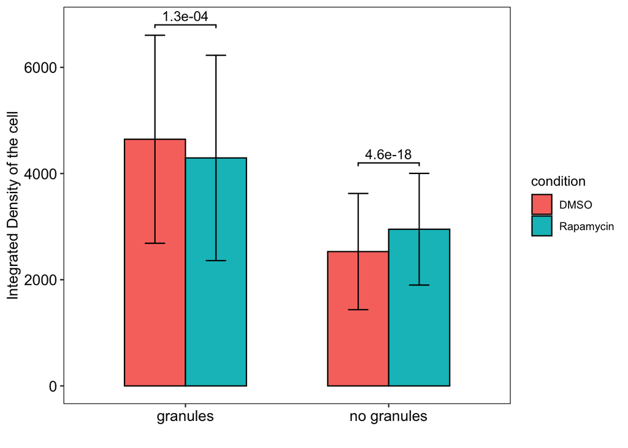

```r
annot1 = c("1.3e-04", "4.6e-18")
y_position1 = c(6800, 4200)
xmin1 = c(0.85, 1.85)
xmax1 = c(1.15, 2.15)

plot_exp1 <- cell_dat_uni_nest %>%
  filter(expday == "exp1") %>%
  ggplot(aes(x= withfoci, y=mean, fill = condition))+
  geom_bar(aes(fill=condition), stat="identity",
           color="black",width = 0.6, position = position_dodge(width = 0.6)) +
  # step_increaseは組み合わせのバーをどれだけずらすかの値
  geom_signif(xmin = xmin1, xmax  =xmax1, y_position =y_position1, annotations = annot1, tip_length = 0.01)+
  geom_errorbar(aes(ymax = mean + sd, ymin = mean - sd), width = 0.2, position = position_dodge(width = 0.6), size = 0.5) +
  # geom_jitter(unnest(cell_dat_uni_nest, cols = data), mapping=aes(x=withfoci, y= cell_intden), size = 1,
  #             alpha=0.8, position = position_jitterdodge(jitter.width = 0.1, jitter.height = 0, dodge.width = .6))+
  ylab("Integrated Density of the cell") +   ## y軸のラベル
  xlab("")+                   ## x軸のラベル
  theme( axis.title.y = element_text(size=12), axis.text.y = element_text(size=12,color = "black"),
         axis.title.x = element_text(size=12), axis.text.x = element_text(size=12,color = "black")
         # ,legend.position = "none" #凡例を消す
         ,panel.border = element_rect(fill = NA, linewidth  = 0.5)# パネルを枠で囲む
         ,panel.background = element_blank()) #背景を白にする
 # facet_grid(~ expday)
plot_exp1
```

exp2のプロット：

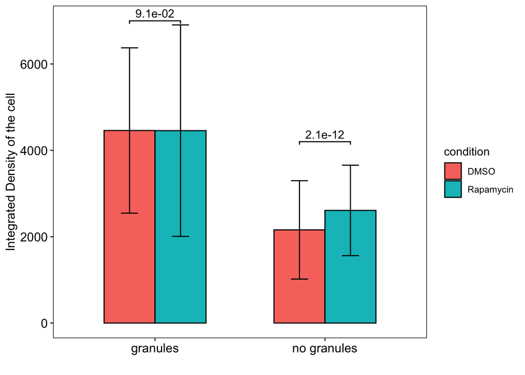

```r
annot2 = c("9.1e-02", "2.1e-12")
y_position2 = c(7000, 4200)
xmin2 = c(0.85, 1.85)
xmax2 = c(1.15, 2.15)

plot_exp2 <- cell_dat_uni_nest %>%
  filter(expday == "exp2") %>%
  ggplot(aes(x= withfoci, y=mean, fill = condition))+
  geom_bar(aes(fill=condition), stat="identity",
           color="black",width = 0.6, position = position_dodge(width = 0.6)) +
  geom_signif(xmin = xmin2, xmax  =xmax2, y_position =y_position2, annotations = annot2, tip_length = 0.01)+
  geom_errorbar(aes(ymax = mean + sd, ymin = mean - sd), width = 0.2, position = position_dodge(width = 0.6), size = 0.5) +
  # geom_jitter(unnest(cell_dat_uni, cols = data), mapping=aes(x=withfoci, y= cell_intden),size = 1,
  #             alpha=0.8, position = position_jitterdodge(jitter.width = 0.1, jitter.height = 0, dodge.width = .6))+
  ylab("Integrated Density of the cell") +   ## y軸のラベル
  xlab("")+                   ## x軸のラベル
  theme( axis.title.y = element_text(size=12), axis.text.y = element_text(size=12,color = "black"),
         axis.title.x = element_text(size=12), axis.text.x = element_text(size=12,color = "black")
         # ,legend.position = "none" #凡例を消す
         ,panel.border = element_rect(fill = NA, linewidth  = 0.5)# パネルを枠で囲む
         ,panel.background = element_blank())#背景を白にする
plot_exp2
```

## 3.3 実験日を区別しない場合

実験日とconditionを区別せずにデータを畳み込んでから、MW testを計算。`unnest()`してから再度`group_nest()`して平均とSDを計算

```r
cell_dat_uni_nest3 <-
  cell_dat_uni %>%
  group_nest(withfoci) %>%
  mutate(mwtest = map(data, ~ wilcox.test(.$cell_intden ~ .$condition, data =., alternative = "two.sided", paired = FALSE)),
        mw_pval = map_dbl(mwtest, ~ .$p.value)) %>%
  dplyr::select(-mwtest) %>%
  unnest(cols = c(data)) %>%
  # mw_pvalでグループ分けすると、畳み込まれない
  group_nest(withfoci, condition, mw_pval) %>%
  mutate(mean = map_dbl(data, ~ mean(.$cell_intden)),
         sd = map_dbl(data, ~ sd(.$cell_intden)),
         N = map_int(data, ~ nrow(.)))
cell_dat_uni_nest3
```

```
## # A tibble: 4 × 7
##   withfoci    condition  mw_pval               data  mean    sd     N
##   <chr>       <fct>        <dbl> <list<tibble[,4]>> <dbl> <dbl> <int>
## 1 granules    DMSO      1.54e- 4        [5,845 × 4] 4554. 1939.  5845
## 2 granules    Rapamycin 1.54e- 4          [388 × 4] 4354. 2139.   388
## 3 no granules DMSO      8.06e-13        [1,354 × 4] 2417. 1121.  1354
## 4 no granules Rapamycin 8.06e-13        [5,479 × 4] 2711. 1060.  5479
```

同様にプロット。

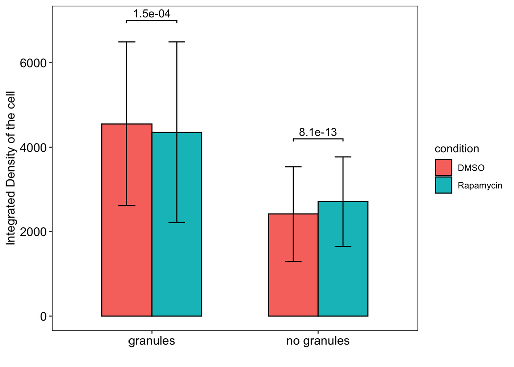

```r
annot3 = c("1.5e-04", "8.1e-13")
y_position3 = c(7000, 4200)
xmin3 = c(0.85, 1.85)
xmax3 = c(1.15, 2.15)

plot3 <- cell_dat_uni_nest3 %>%
  ggplot(aes(x= withfoci, y=mean, fill = condition))+
  geom_bar(aes(fill=condition), stat="identity",
           color="black",width = 0.6, position = position_dodge(width = 0.6)) +
  # step_increaseは組み合わせのバーをどれだけずらすかの値
  geom_signif(xmin = xmin3, xmax  =xmax3, y_position =y_position3, annotations = annot3, tip_length = 0.01)+
  geom_errorbar(aes(ymax = mean + sd, ymin = mean - sd), width = 0.2, position = position_dodge(width = 0.6), size = 0.5) +
  # geom_jitter(unnest(cell_dat_uni, cols = data), mapping=aes(x=withfoci, y= cell_intden),size = 1,
  #             alpha=0.8, position = position_jitterdodge(jitter.width = 0.1, jitter.height = 0, dodge.width = .6))+
  ylab("Integrated Density of the cell") +   ## y軸のラベル
  xlab("")+                   ## x軸のラベル
  theme( axis.title.y = element_text(size=12), axis.text.y = element_text(size=12,color = "black"),
         axis.title.x = element_text(size=12), axis.text.x = element_text(size=12,color = "black")
         # ,legend.position = "none" #凡例を消す
         ,panel.border = element_rect(fill = NA, linewidth  = 0.5)# パネルを枠で囲む
         ,panel.background = element_blank())#背景を白にする
plot3
```

## 3.4 視野毎にデータを平均化

各視野における細胞内総輝度を平均化してから解析。`image_file`毎に`cell_intden`の平均値を求める。その後はデータを畳み込んで、同様にMW testを適用し、平均とSDを計算。

```r
cell_dat_uni_pfv <- cell_dat_uni %>%
  group_by(image_file, condition, withfoci) %>%
  summarise(cell_intden_pfv = mean(cell_intden))
cell_dat_uni_pfv
```

```
## # A tibble: 66 × 4
## # Groups:   image_file, condition [33]
##    image_file        condition withfoci    cell_intden_pfv
##    <chr>             <fct>     <chr>                 <dbl>
##  1 Ade4_mNG_dmso_001 DMSO      granules              3797.
##  2 Ade4_mNG_dmso_001 DMSO      no granules           2059.
##  3 Ade4_mNG_dmso_002 DMSO      granules              4278.
##  4 Ade4_mNG_dmso_002 DMSO      no granules           2214.
##  5 Ade4_mNG_dmso_003 DMSO      granules              4521.
##  6 Ade4_mNG_dmso_003 DMSO      no granules           2206.
##  7 Ade4_mNG_dmso_004 DMSO      granules              4520.
##  8 Ade4_mNG_dmso_004 DMSO      no granules           2380.
##  9 Ade4_mNG_dmso_005 DMSO      granules              5028.
## 10 Ade4_mNG_dmso_005 DMSO      no granules           1947.
## # ℹ 56 more rows
```

```r
cell_dat_uni_pfv_nest <- cell_dat_uni_pfv %>%
  # いったんungroup()しないとエラー
  ungroup() %>%
  group_nest(withfoci) %>%
  mutate(mwtest = map(data, ~ wilcox.test(.$cell_intden_pfv ~ .$condition, data =., alternative = "two.sided", paired = FALSE)),
         mw_pval = map_dbl(mwtest, ~ .$p.value)) %>%
  dplyr::select(-mwtest) %>%
  unnest(cols = c(data)) %>%
  # mw_pvalでグループ分けすると、畳み込まれない
  group_nest(withfoci, condition, mw_pval) %>%
  mutate(mean = map_dbl(data, ~ mean(.$cell_intden_pfv)),
         sd = map_dbl(data, ~ sd(.$cell_intden_pfv)),
         N = map_int(data, ~ nrow(.)))
cell_dat_uni_pfv_nest
```

```
## # A tibble: 4 × 7
##   withfoci    condition     mw_pval               data  mean    sd     N
##   <chr>       <fct>           <dbl> <list<tibble[,2]>> <dbl> <dbl> <int>
## 1 granules    DMSO      0.168                 [17 × 2] 4589.  440.    17
## 2 granules    Rapamycin 0.168                 [16 × 2] 4367.  407.    16
## 3 no granules DMSO      0.000000871           [17 × 2] 2262.  227.    17
## 4 no granules Rapamycin 0.000000871           [16 × 2] 2796.  210.    16
```

結果をExcelファイルに保存。

```r
cell_dat_uni_pfv_nest %>%
  dplyr::select(-data) %>%
  write.xlsx(., "nest_pfv_mean_sd.xlsx", colNames = TRUE, sheetName = "221027-28")
```

結果をプロット。データポイントが少ないので各点をプロット。また実験日を区別しない。

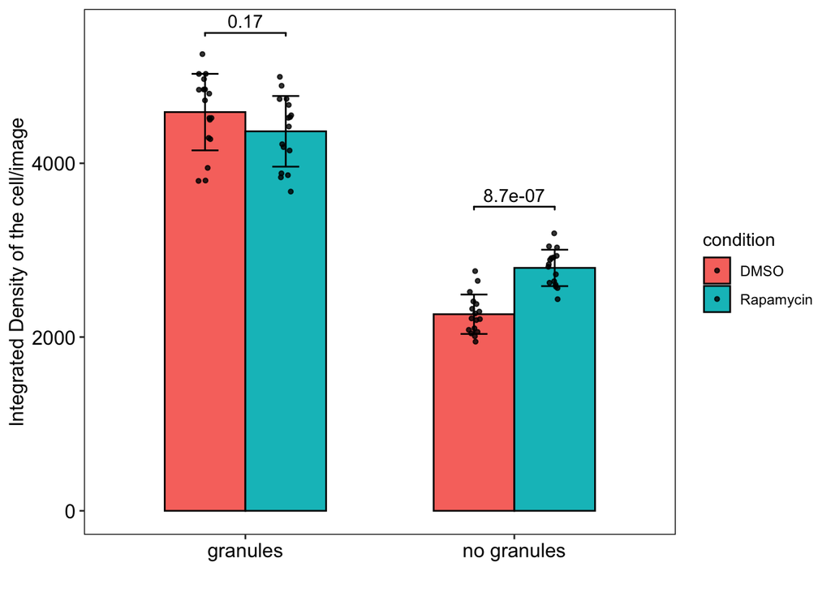

```r
annot4 = c("0.17", "8.7e-07")
y_position4 = c(5500, 3500)
xmin4 = c(0.85, 1.85)
xmax4 = c(1.15, 2.15)

plot_pfv <- cell_dat_uni_pfv_nest %>%
  ggplot(aes(x= withfoci, y=mean, fill = condition))+
  geom_bar(aes(fill=condition), stat="identity",
           color="black",width = 0.6, position = position_dodge(width = 0.6)) +
  geom_signif(xmin = xmin4, xmax  =xmax4, y_position =y_position4, annotations = annot4, tip_length = 0.01)+
  geom_errorbar(aes(ymax = mean + sd, ymin = mean - sd), width = 0.2, position = position_dodge(width = 0.6), size = 0.5) +
  geom_jitter(unnest(cell_dat_uni_pfv_nest, cols = data), mapping=aes(x=withfoci, y= cell_intden_pfv),size = 1,
              alpha=0.8, position = position_jitterdodge(jitter.width = 0.1, jitter.height = 0, dodge.width = .6))+
  ylab("Integrated Density of the cell/image") +   ## y軸のラベル
  xlab("")+                   ## x軸のラベル
  theme( axis.title.y = element_text(size=12), axis.text.y = element_text(size=12,color = "black"),
         axis.title.x = element_text(size=12), axis.text.x = element_text(size=12,color = "black")
         # ,legend.position = "none" #凡例を消す
         ,panel.border = element_rect(fill = NA, linewidth  = 0.5)# パネルを枠で囲む
         ,panel.background = element_blank())#背景を白にする
plot_pfv
```